# Transparent Conductors Predictions

##### Execute the `PlotAll()` Method

This method will plot the main results (scores and standard deviations)

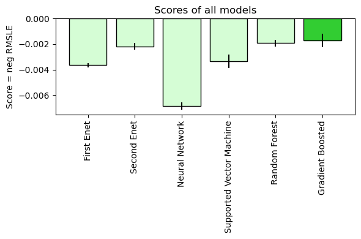

```python
DF_3_1.PlotAll()
```

##### Visualize how the hyper parameters affected the performance of the model

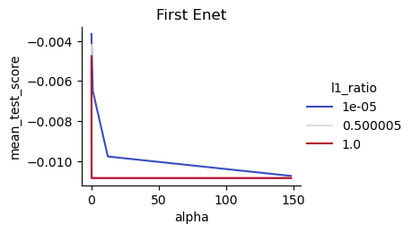

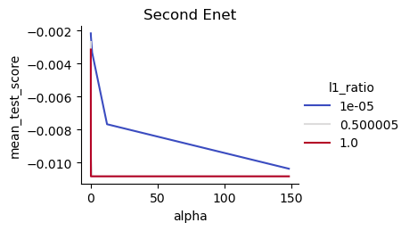

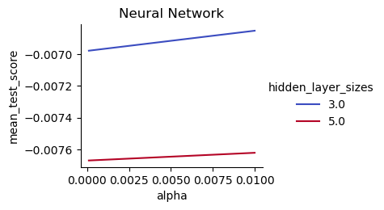

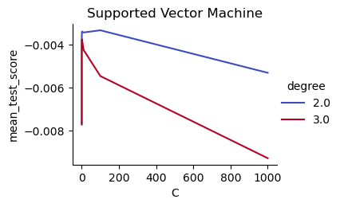

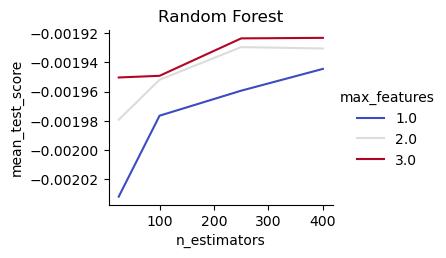

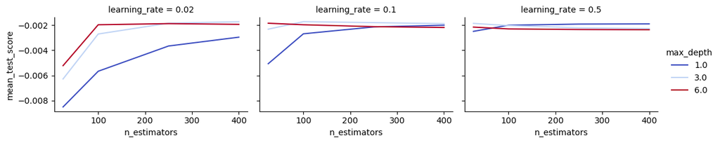

```python
DF_3_1.PlotEachModel()
```

##### Analyze the random forest

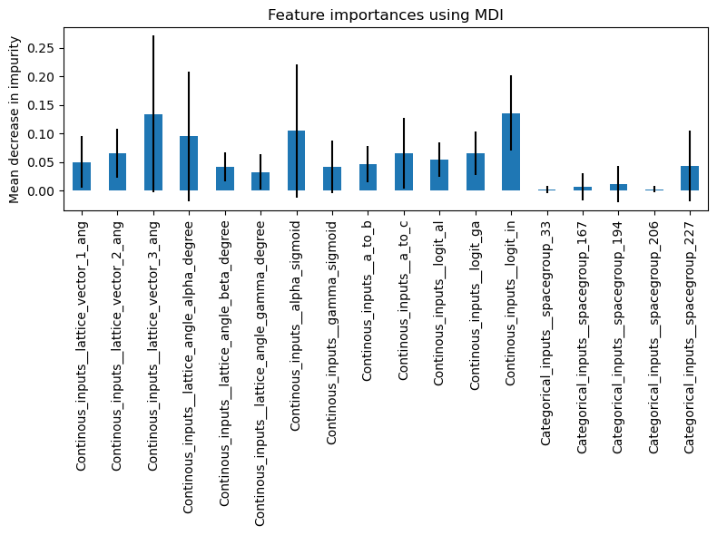

```python
DF_3_1.EvaluateRandomForest()
```

### Fit the log bandgap

##### Initialize the DataFit object

```python
DF_3_2 = DataFit(prepro_df_train, continous_inputs=input_list, categorical_inputs=categorical_list, output=output_list[1], use_PCA = False)
```

##### Execute the `FitAll()` Method

This method will fit all the models, store the results as attributes

```python
DF_3_2.FitAll()
```

[output not shown]

##### Execute the `PlotAll()` Method

This method will plot the main results (scores and standard deviations)

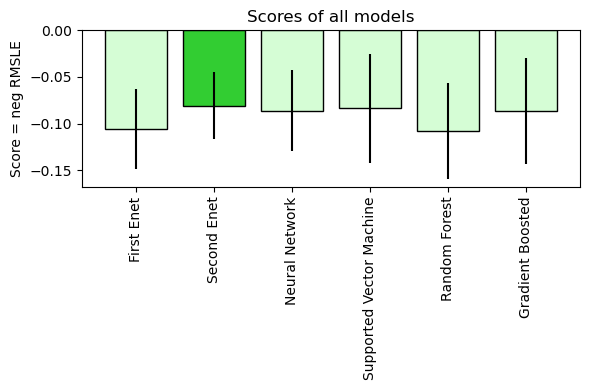

```python
DF_3_2.PlotAll()
```

##### Visualize how the hyper parameters affected the performance of the model

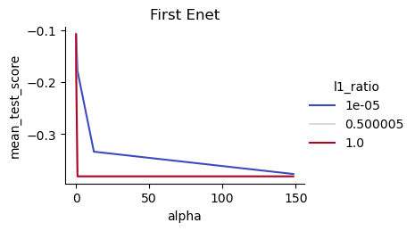

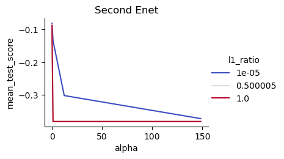

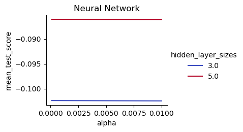

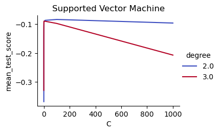

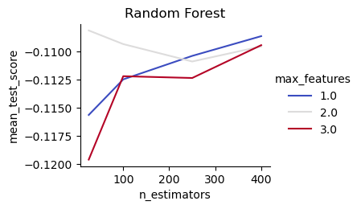

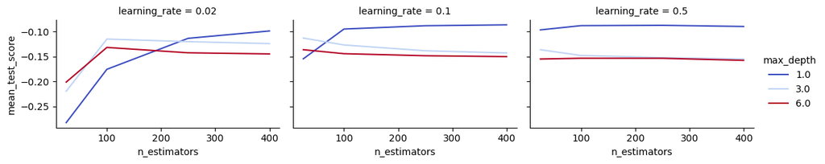

```python
DF_3_2.PlotEachModel()
```

##### Analyze the random forest

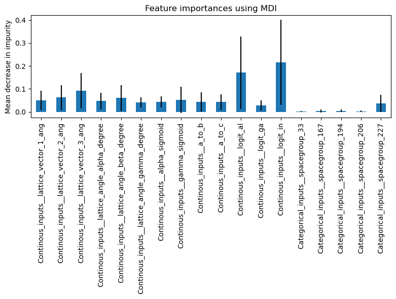

```python
DF_3_2.EvaluateRandomForest()
```

### Save the predictions into a csv file

```python
pd.DataFrame({'formation_energy_ev_natom' : DF_3_1.GBM_results.predict(prepro_df_test),
                          'bandgap_energy_ev' : 10**DF_3_2.SecondEnet_results.predict(prepro_df_test)},
                         index=prepro_df_test.id.copy()).to_csv('Third_models.csv')
```

## Fit the fourth series of models

- Categorical to consider: `number_of_total_atoms`. `spacegroup` is not considered at all.
- Continous variables: Will include the new-generated variables
- PCA? No

### Define the helping lists of inputs, outputs and categorical variables

```python
output_list = ['formation_energy_ev_natom', 'log_bandgap']

categorical_list = ['number_of_total_atoms_cat']

exclude_list = ['alpha_theory', 'gamma_theory', 'id', 'percent_atom_al', 'percent_atom_in', 'percent_atom_ga', 'number_of_total_atoms', 'spacegroup',
                 'alpha_comparisson', 'gamma_comparisson', 'bandgap_energy_ev', 'binary_number_of_total_atoms']

input_list = [var for var in prepro_df_train.columns.to_list() if var not in output_list+categorical_list+exclude_list]
```

##### Initialize the DataFit object

```python
DF_4_1 = DataFit(prepro_df_train, continous_inputs=input_list, categorical_inputs=categorical_list, output=output_list[0], use_PCA = False)
```

##### Execute the `FitAll()` Method

This method will fit all the models, store the results as attributes

```python
DF_4_1.FitAll()
```

[output not shown]

##### Execute the `PlotAll()` Method

This method will plot the main results (scores and standard deviations)

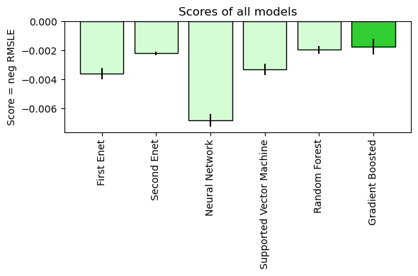

```python
DF_4_1.PlotAll()
```

##### Visualize how the hyper parameters affected the performance of the model

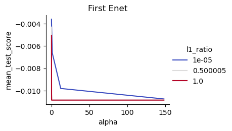

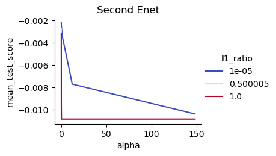

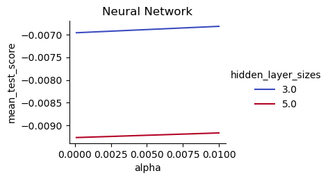

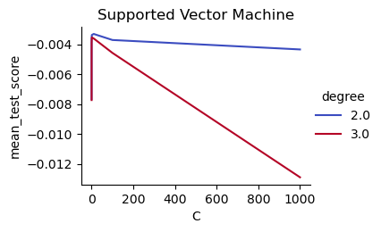

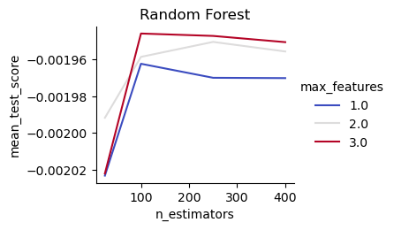

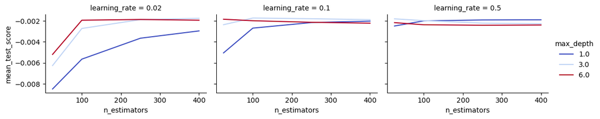

```python
DF_4_1.PlotEachModel()
```

##### Analyze the random forest

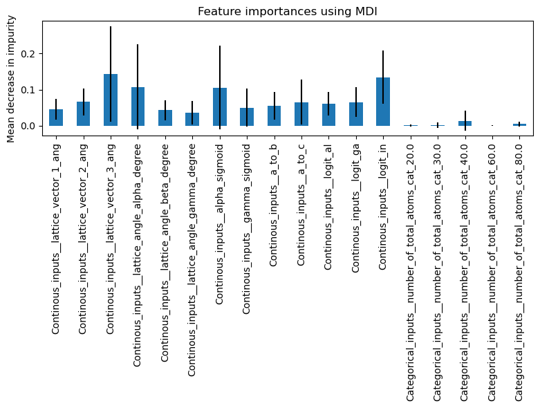

```python
DF_4_1.EvaluateRandomForest()
```

### Fit the log bandgap

##### Initialize the DataFit object

```python
DF_4_2 = DataFit(prepro_df_train, continous_inputs=input_list, categorical_inputs=categorical_list, output=output_list[1], use_PCA = False)
```

##### Execute the `FitAll()` Method

This method will fit all the models, store the results as attributes

```python
DF_4_2.FitAll()
```

[output not shown]

##### Execute the `PlotAll()` Method

This method will plot the main results (scores and standard deviations)

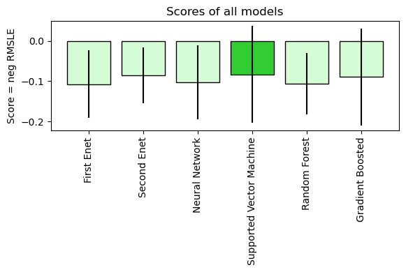

```python
DF_4_2.PlotAll()
```

##### Visualize how the hyper parameters affected the performance of the model

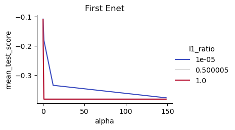

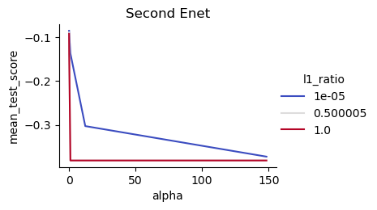

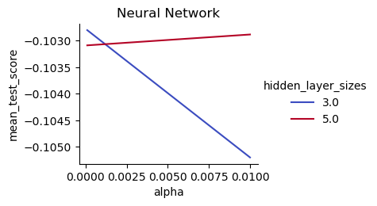

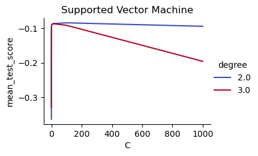

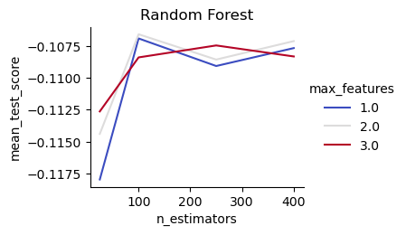

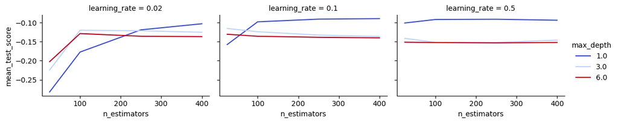

```python
DF_4_2.PlotEachModel()
```

##### Analyze the random forest

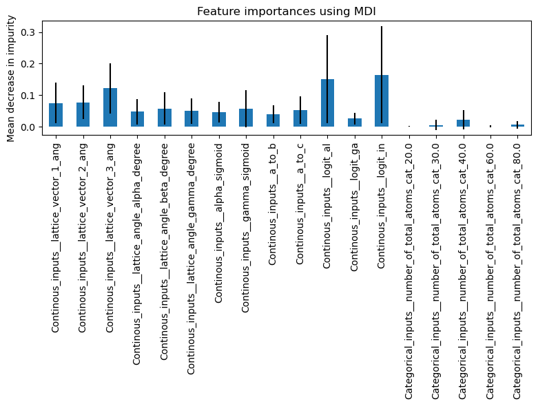

```python
DF_4_2.EvaluateRandomForest()
```

### Save the predictions into a csv file

```python
pd.DataFrame({'formation_energy_ev_natom' : DF_4_1.GBM_results.predict(prepro_df_test),
                          'bandgap_energy_ev' : 10**DF_4_2.SecondEnet_results.predict(prepro_df_test)},
                         index=prepro_df_test.id.copy()).to_csv('Fourth_models.csv')
```

# Final Takeaways

### Which model was best?

In general, the second elastic net model (the one considering polynomial features), and the Gradient Boosted Regressors were the models that had the best overall scores for the training data using cross-validation. It is worth mentioning that, although surprising in appearance, the neural network model wasn't preferred in any case, despite the non-linear nature of the problem. This is in large ammount caused by the small number of hidden layers chosen and the small sampling space of the hyper-parameter tuning grid (due to computational cost).

Overall, and as it can be found in the `Kaggle_Scores.csv` file, the performance of all models was similar and overall poor. The best overall feature-set turned out to be the second, which involved using PCA.

To improve the performance of the models, some extra features to consider can include the distances between atoms, the angles between them, and other user element-dependent properties.

All in all, the project was a good experience to deepen the knowledge of different models, and the use of scikit learn.

### What are the most important features according to the Random Forest model?

The most important features include the length of the third lattice vector, the lattice angle alpha and the concentration of element In. Some rankings included the concentration of Al, which was a variable I expected to have a large impact (based on the EDA). It surprised me to see many Random forests that didn't include this variable as one of the most importants. Additionally, the lattice angle beta was not included, which, again turned to be surprising since the EDA seemed to suggest otherwise.